# Coursework Report

*N* removed NAs: 3

*N* removed typo: 1

*N* removed <18: 19

*N* total clean: 127

| Group | *N* | *M*<sub>age</sub> | *M*<sub>rating</sub> |
| --- | --- | --- | --- |
| Control | 62 | 21.27 | 6.00 |
| Experim | 65 | 20.48 | 7.06 |

**Main analysis results**

*t*(125) = -6.69, *p* < .001

[interactive chart not shown]

[figure not shown]

[interactive chart not shown]

# Coursework Report

Analysing Data, Spring 2020

```
## # A tibble: 1 x 4
##    mean    sd   min   max
##   <dbl> <dbl> <dbl> <dbl>
## 1  21.4  2.04    19    28
```

Table 1 *Descriptive statistics by categories of condition*

| CONDITION | *N* | % | *M*<sub>ITEM_comp</sub> | *SD*<sub>ITEM_comp</sub> |
| --- | --- | --- | --- | --- |
| white | 58 | 54.71698 | 6.005747 | 0.8863078 |
| red | 48 | 45.28302 | 7.125000 | 0.8687509 |

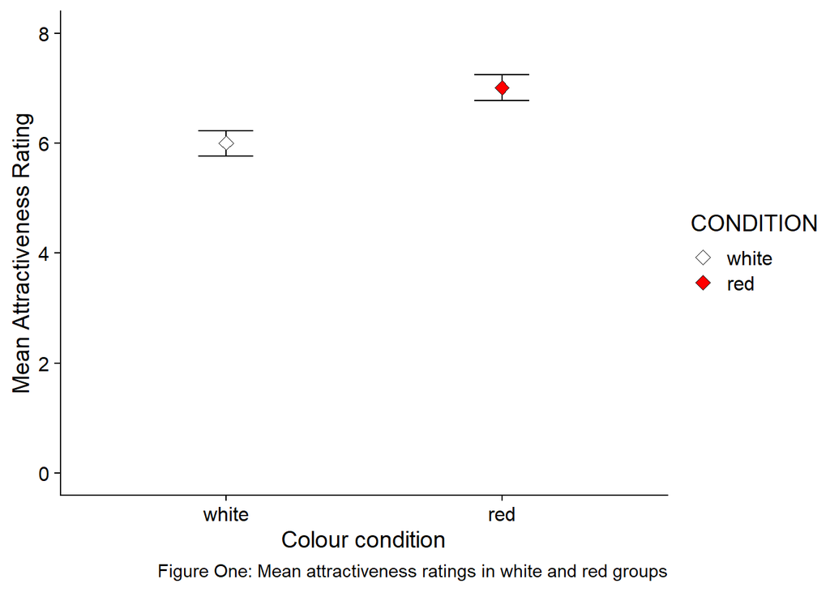

```
##
##  Two Sample t-test
##
## data:  ITEM_comp by CONDITION
## t = -6.5299, df = 104, p-value = 0.000000002464
## alternative hypothesis: true difference in means is not equal to 0
## 95 percent confidence interval:
##  -1.4591519 -0.7793538
## sample estimates:
## mean in group white   mean in group red
##            6.005747            7.125000
```

# Methods

## Participants

This study intially used 150 participants who were all female but the final sample number of participants used were 106 (*M*<sub>AGE</sub> = 21.43, *SD*<sub>age</sub> = 2.04). This is because data consisting of improbable values were removed in addition to 12 participants who were removed for ethical reasons as they were under eighteen years of age.

## Design

This study is a replication of the first part of an experiment conducted by Elliot et al, 2009. In this replication participants viewed a photo of a man either on a white or red frame and were then asked to complete three questions to assess their perceived attractiveness towards the male. This study used an independent measures design where each participant was only exposed to one condition (either red or white). The white frame acted as a control and the experimental condition used a red frame to see if the colour of the frame made a difference to perceived attractiveness. This study proposed that the red frame will produce higher attractiveness ratings. Three questions (Items) were asked and each had a scale ranging from one to nine, with nine being extremely attractive and one being not attractive at all. Item one was “How attractive do you think this person is?” Item two was “How pleasant is this person to look at?” and item three was “If I were to meet the person in this picture face to face, I would think he is attractive.” A t-test will be used to examine whether there will be a significant difference between the colour of the frame and perceived attractiveness. This study proposed that the red frame will produce higher attractiveness ratings than the white frame.

# Results

# Discussion

The purpose of this study was to investigate whether the colour red increases women’s perceived attraction towards men. The results from this experiment supports our hypothesis as there was a significant difference between the participants in the red condition compared to the participants in the white condition. Participants in the red condition had a higher mean of the three questions compared to the white condition.

This experiment is a replication of the first part of the study conducted by Elliot et al,2009, and the results were also very similar to each other. Elliot’s study and the current replication highlighted a significant difference between the red and white condition, providing evidence that a red background does increase attractiveness towards men. Furthermore, Young (2015) also emphasised that the ‘red effect’ also has an influence in attraction of men towards women. This study revealed that men perceived women as more attractive when she wore a red item of clothing. Although Young (2015) showed perceived attraction towards women, it still highlights that red does have an influence in attraction in not only men but also women. This is further emphasised in Peperkoorn, Roberts & Pollet (2016) study where women gave higher attractiveness ratings for men who were on a red background compared to a grey background when they were ovulating which also links and supports the current replication.

However, other studies have shown the opposite effect. Hesslinger, Goldbach, & Carbon (2015) also replicated the first part of the study by Elliot et al (2009) but found no significant difference between red and attractivness. Instead what they found was that men who wore more formal clothing rated higher in attractivness for women compared to if they wore causual clothes. This could suggest that there are other bigger factors that influence attractiveness, not just the colour red.

A strength of this experiment is that it is an independent measures design which means different women (our participants) are used in each condition. This is advantageous because there are no order effects, allowing the participants not to get tired or well rehearsed over the same repeated questions on attractiveness of the photograph. In addition to this, an independent design also reduces the chances of participants figuring out what the purpose of the experiment is and therefore adjusting their answers accordingly, which in this case is about whether red increases attractiveness ratings.

One weakness of this experiment is that there could be potential confounding variables. For example, the male in the photo could have other features which are seen as attractive other than the colour of the frame. For example, a study conducted by Weeden and Sabina (2005) revealed that women are attracted to men who have masculine features, such as a sharp jawline. The three questions that participants were asked did not indicate what specific factor of the male makes him more attractive. This means we cannot fully comment on whether it is red that is causing the change in attraction ratings. Perhaps this can be improved in a future study by asking an additional question that addresses this issue in order to get a better clarification on what actually determines attractiveness. In addition to this, another limitation of this experiment was that the study did not include middle-aged women which means we do not know if red has an effect on attraction for ALL women. Future studies can focus on different age groups to determine if the colour red still shows the same consistent results.

A potential future study would be to see whether a person’s preference to a particular colour will make a difference in attraction ratings. For example, if a person disliked the colour red, would it make them more likely to give another person a low attractiveness rating if he/she was wearing a red item of clothing? Participants would first be asked to choose their favourite colour from a list. A photo of a man wearing a t-shirt of those colours will be shown to the participants who then select which is the most attractive. This could help explain the underlying cause of why red (or other colours) make people seem more attractive.

# References

Elliot, A. J., Niesta Kayser, D., Greitemeyer, T., Lichtenfeld, S., Gramzow, R. H., Maier, M. A., & Liu, H. (2010). Red, rank, and romance in women viewing men. *Journal of Experimental Psychology: General, 139*(3), 399.

Hesslinger, V.M., Goldbach, L. & Carbon, C (2015). Men in red: A reexamination of the red-attractiveness effect. *Psychon Bull Rev 22, 1142–1148.*

Peperkoorn, L. S., Roberts, S. C., & Pollet, T. V. (2016). Revisiting the red effect on attractiveness and sexual receptivity: No effect of the color red on human mate preferences. *Evolutionary Psychology, 14*(4), 1–13.

Young, S. (2015). The effect of red on male perceptions of female attractiveness: Moderation by baseline attractiveness of female faces. *European Journal of Social Psychology, 45*(2), pp.146-151.**